# Création de cartes choroplèthes avec {ggplot2}

## 5.2 Personnalisation de la Carte

Nous pouvons personnaliser la carte en ajoutant des titres aux axes et à la légende, en ajoutant une flèche du nord et une barre d’échelle avec `ggspatial::annotation_north_arrow()` et `ggspatial::annotation_scale()`, et en changeant le thème pour `theme_bw()`.

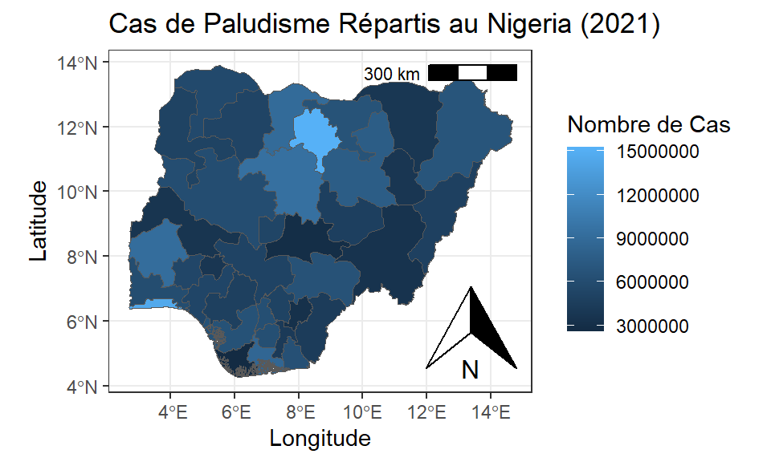

```r
ggplot(data=malaria2) +
  geom_sf(aes(fill=cases_2021)) +   # régler le remplissage pour varier selon la variable de nombre de cas
  labs(title = "Cas de Paludisme Répartis au Nigeria (2021)",
       fill = "Nombre de Cas") +
  xlab("Longitude")+
  ylab("Latitude")+
  ggspatial::annotation_north_arrow(location = "br")+
  ggspatial::annotation_scale(location = "tr")+
  theme_bw()
```

Dans cette section, nous avons d’abord créé une carte choroplèthe de base en utilisant {ggplot2} pour visualiser les cas régionaux de paludisme au Nigeria pour 2021. Ensuite, nous avons amélioré la carte en ajoutant des **titres**, des **étiquettes d’axes**, une **flèche du nord**, une **barre d’échelle** et en appliquant un **thème** monochrome.

**Q : Construisez votre magnifique carte choroplèthe**

Construisez une carte choroplèthe pour afficher la distribution des cas de paludisme en 2015, en utilisant la colonne `cases_2015` du jeu de données `malaria2`. Vous pouvez améliorer la conception et la clarté de votre carte en intégrant des titres, des étiquettes d’axes et toute autre étiquette pertinente.

# 6 Mise à l’échelle des Couleurs

## 6.1 Mise à l’échelle des Couleurs Continue

La fonction `scale_fill_continuous()` du package {ggplot2} dans R est utilisée pour appliquer une échelle de couleurs continue à une carte choroplèthe.

Nous pouvons personnaliser la palette de couleurs utilisée pour l’échelle de couleurs continue en spécifiant les paramètres `low` et `high` dans la fonction `scale_fill_continuous()`.

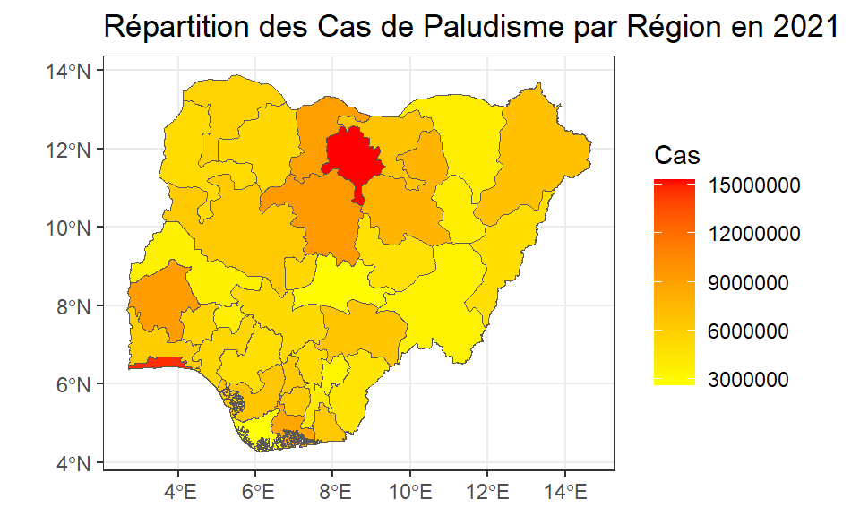

```r
# Créer un objet ggplot
ggplot(data = malaria2) +
  geom_sf(aes(fill = cases_2021)) +
  scale_fill_continuous(low = "yellow", high = "red", name = "Cas") + # appliquer une échelle de couleurs continue
  ggtitle("Répartition des Cas de Paludisme par Région en 2021") + # Ajouter le titre corrigé ici
  theme_bw()
```

Dans cette section, nous avons appris comment appliquer une échelle de couleurs continue à une carte choroplèthe en utilisant la fonction `scale_fill_continuous()` du package {ggplot2} dans R et comment personnaliser la palette de couleurs.

## 6.2 Mise à l’échelle des Couleurs Discrete

La fonction `scale_fill_brewer()` du package {ggplot2} dans R est utilisée pour appliquer une échelle de couleurs discrète à une carte choroplèthe.

Avant d’appliquer l’échelle de couleurs discrète, nous devrons créer une nouvelle colonne discrète, qui pourrait être un niveau de risque basé sur le nombre de cas. Pour cela, nous pouvons utiliser `mutate()` combiné avec `case_when()`.

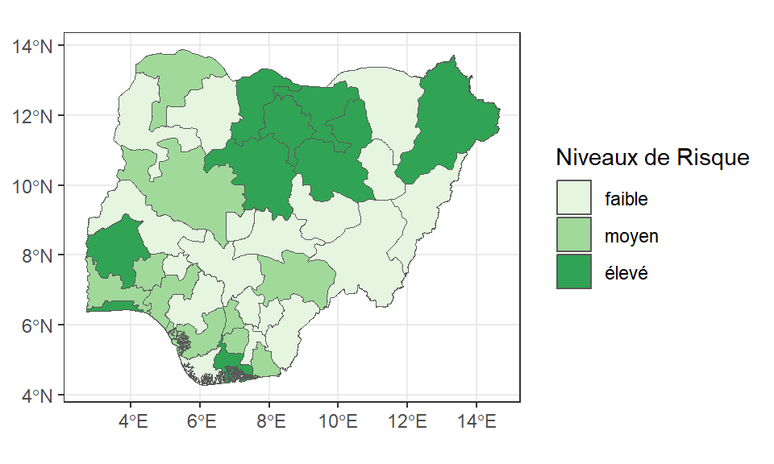

```r
# Transformer les données : Créer une nouvelle colonne 'risk' basée sur le nombre de cas en 2021
malaria3 <- malaria2 %>%
  mutate(risk = case_when(cases_2021 < quantile(cases_2021, 0.5) ~ 'faible',
                          cases_2021 > quantile(cases_2021, 0.75) ~ 'élevé',
                          TRUE ~ 'moyen'))

# Visualiser les données
ggplot(data = malaria3) +
  geom_sf(aes(fill =  fct_reorder(risk, cases_2021)))+ # Les niveaux de risque sont réordonnés en fonction du nombre de cas
  scale_fill_brewer(palette = "Set4", "Niveaux de Risque")+
  theme_bw()
```

Vous pouvez également créer une palette de couleurs personnalisée pour les variables discrètes.

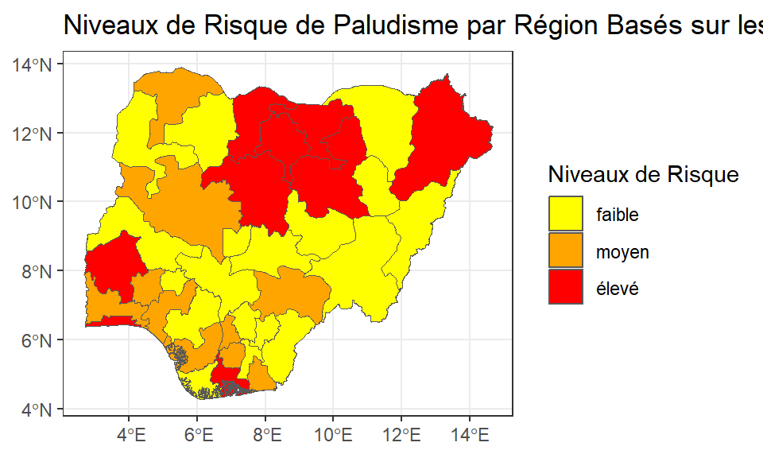

```r
palette_personnalisée <- c("yellow", "orange", "red") # créer une palette de couleurs personnalisée manuellement

# Appliquer la palette de couleurs personnalisée
ggplot(data = malaria3) + # Créer un objet ggplot
   geom_sf(aes(fill =  fct_reorder(risk, cases_2021))) + # réordonner les étiquettes de risque selon le nombre de cas
   scale_fill_manual(values = palette_personnalisée, name = "Niveaux de Risque") +
   coord_sf(expand = TRUE) +
   ggtitle("Niveaux de Risque de Paludisme par Région Basés sur les Cas de 2021") + # Ajouter un titre ici
   theme_bw()
```

Dans cette section, nous avons appris comment appliquer une échelle de couleurs discrète à une carte choroplèthe en utilisant la fonction `scale_fill_brewer()` du package {ggplot2} et comment personnaliser la palette de couleurs.

**Q : Créez votre propre palette de couleurs**

Créez votre propre palette de couleurs distincte de celle initiale, et affichez les cas de paludisme à travers le Nigeria pour 2000 en utilisant cette palette personnalisée. N’oubliez pas d’intégrer des améliorations esthétiques supplémentaires.

# 7 Facet Wrap vs. Grille

- `facet_wrap()`: Cette fonction enveloppe une séquence 1D de panneaux en 2D. C’est utile lorsque vous avez une seule variable avec de nombreux niveaux et que vous souhaitez organiser les graphiques de manière plus efficace en termes d’espace.
- `facet_grid()`: Cette fonction crée une matrice de panneaux définis par des variables de facettage en lignes et en colonnes. Elle est la plus utile lorsque vous avez deux variables discrètes et que toutes les combinaisons de variables existent dans les données.
- `facet_wrap()` est utilisé pour le facettage d’une seule variable, tandis que `facet_grid()` est utilisé pour le facettage de deux variables.
- `facet_wrap()` organise les panneaux en grille 2D, tandis que `facet_grid()` les organise en matrice.

## 7.1 Création de petits multiples avec `facet_wrap()`

Nous pouvons utiliser la fonction `facet_wrap()` pour créer de multiples petits graphiques basés sur une variable donnée. Dans l’exemple suivant, nous pouvons utiliser la variable `année`.

Rappelez-vous que l’échelle des couleurs peut être ajustée par `scale_fill_continuous()` si la variable est continue ou par `scale_fill_brewer()` si la variable est discrète.

Ici, nous devons faire un léger ajustement à la structure de notre jeu de données. Puisque les cas sont présentés par année et que chaque année est représentée dans une colonne séparée, nous utiliserons la fonction `pivot_longer()` pour les consolider dans une seule colonne, accompagnée d’une clé d’identifiant.

```r
malaria3_longer <- malaria3 %>%
  pivot_longer(cols = `cases_2000`:`cases_2021`, names_to = "year", values_to = "cases")
```

Il semble que la variable `année` dans notre jeu de données ait un préfixe `cases_` que nous aimerions supprimer pour des raisons esthétiques avant de tracer.

Voici comment nous pouvons le faire en utilisant la fonction `str_replace()` du package {stringr}, qui fait partie du tidyverse :

```r
# Recoder la variable 'année' en supprimant le préfixe 'cases_'
malaria3_longer$year <- str_replace(malaria3_longer$year, "cases_", "")
```

Après avoir exécuté le code ci-dessus, la variable `année` dans notre jeu de données `malaria3_longer` n’aura plus le préfixe `cases_`, la rendant plus propre pour des fins de visualisation.

Maintenant, nous voulons créer de multiples petits graphiques en utilisant `facet_wrap()`.

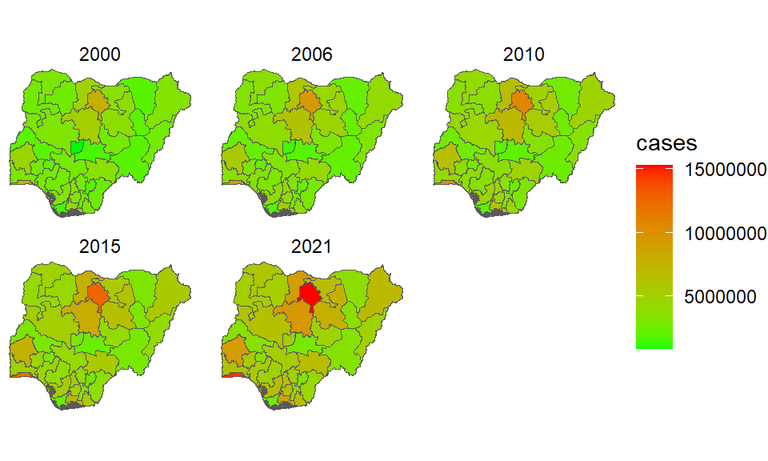

```r
# Créer un objet ggplot en utilisant facet_wrap
ggplot(data = malaria3_longer) +
  geom_sf(aes(fill = cases)) +
  facet_wrap(~ year)+
  scale_fill_continuous(low = "green", high = "red") + # appliquer l'échelle de couleur continue
  theme_void()
```

Nous pouvons ajouter une autre variable au `facet_wrap()`. Ici, nous ajoutons `risk`, mais nous utiliserons uniquement les cas de 2000 et 2021 à des fins de démonstration :

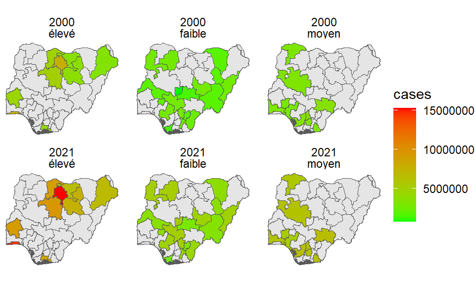

```r
ggplot() +
  geom_sf(data = nga_adm1) +
  geom_sf(aes(fill = cases), data = filter(malaria3_longer, year %in% c("2000", "2021"))) +
  facet_wrap(year ~ risk)+
  coord_sf(expand = TRUE)+
  scale_fill_continuous(low = "green", high = "red")+
  theme_void()
```

Dans le dernier graphique ci-dessous, vous remarquerez que nous avons utilisé une variable de remplissage continue, mais nous avons également utilisé un `facet_wrap` sur deux autres variables discrètes.